# asanchezmaz-PEC1

Alberto Sánchez Mazarro

3/23/2020

## Ejercicio 1:

Estudia los tres casos siguientes y contesta, de forma razonada la pregunta que se realiza:

- Disponemos de un conjunto de variables referentes a vehículos, tales como la marca, modelo, año de matriculación, etc. También se dispone del precio al que se vendieron. Al poner a la venta a un nuevo vehículo, se dispone de las variables que lo describen, pero se desconoce el precio. ¿Qué tipo de algoritmo se debería aplicar para predecir de forma automática el precio?
- En un almacén de naranjas se tiene una máquina, que de forma automática obtiene un conjunto de variables de cada naranja, como su tamaño, acidez, grado maduración, etc. Si se desea estudiar las naranjas por tipos, según las variables obtenidas, ¿qué tipo de algoritmo es el más adecuado?
- Un servicio de música por internet dispone de los historiales de audición de sus clientes: Qué canciones y qué grupos eligen los clientes a lo largo del tiempo de sus escuchas. La empresa desea crear un sistema que proponga la siguiente canción y grupo en función de la canción que se ha escuchado antes. ¿Qué tipo de algoritmo es el más adecuado?

### Respuesta 1:

En el ejemplo de los vehículos creo que se trata de un aprendizaje supervisado con algoritmos de regresión. A partir de una historia previa con un conjunto de entradas (características del coche) del que se conocen las salidas (el precio) se pretende predecir el precio de coches con características similares a las que se tienen en el conjunto inicial.

En el ejemplo de las naranjas, creo que se debería usar un algotirmo no supervisado de agregación. A partir de las características comunes de los elementos (las naranjas), se pretende agruparlas en conjuntos en función de que tengan propiedades similares.

Para el ejemplo tres creo que sería adecuado que el sistema constara de dos algoritmos: uno supervisado para aprender lo que ha escuchado el usuario con anterioridad de modo que sepamos qué estilo o grupos de música escucha y otro no supervisado de agregación que tenga agrupadas las canciones en “grupos similares” de modo que se pueda relacionar las canciones anteriormente escuchadas por el usuario con canciones “similares” todavía por escuchar.

## Ejercicio 2:

A partir del conjunto de datos disponible en el siguiente enlace http://archive.ics.uci.edu/ml/datasets/Adult , realiza un estudio tomando como propuesta inicial al que se ha realizado con el conjunto de datos “Titanic”. Amplia la propuesta generando nuevos indicadores o solucionando otros problemas expuestos en el módulo 2. Explica el proceso que has seguido, qué conocimiento obtienes de los datos, qué objetivo te has fijado y detalla los pasos, técnicas usadas y los problemas resueltos.

Nota: Si lo deseas puedes utilizar otro conjunto de datos propio o de algún repositorio open data siempre que sea similar en diversidad de tipos de variables al propuesto.

### Respuesta 2

Para la realización del ejercicio me he basado en lo aprendido durante las prácticas voluntarias del módulo y en el ejercicio de ejemplo que se explicaba en la PEC.

Adicionalmente, he encontrado la página https://rstudio-pubs-static.s3.amazonaws.com/235617_51e06fa6c43b47d1b6daca2523b2f9e4.html que me ha servido para alguna consulta y entender mejor los datos, pero he intentado desmarcarme de los ejemplos ahí mostrados a fin de poder desarrollar los míos propios.

```r
library(ggplot2)
library(dplyr)
# Cargamos el juego de datos
datosAdult <- read.csv('http://archive.ics.uci.edu/ml/machine-learning-databases/adult/adult.data',stringsAsFactors = FALSE, header = FALSE)

# Nombres de los atributos
names(datosAdult) <- c("age","workclass","fnlwgt","education","education-num","marital-status","occupation","relationship","race","sex","capital-gain","capital-loss","hour-per-week","native-country","income")

#Vemos la dimensión del dataSet que es de 32561 x 15
dim (datosAdult)
```

```
## [1] 32561    15
```

```r
#Guardo en variables el número de filas y columnas por comodidad posterior al manipular o estudiar los datos
filas=dim(datosAdult[1])
columnas=dim(datosAdult[2])

#Verifico la esructura del conjunto, lo que me indica el tipo de cada uno de los atributos
str(datosAdult)
```

```
## 'data.frame':    32561 obs. of  15 variables:
##  $ age           : int  39 50 38 53 28 37 49 52 31 42 ...
##  $ workclass     : chr  " State-gov" " Self-emp-not-inc" " Private" " Private" ...
##  $ fnlwgt        : int  77516 83311 215646 234721 338409 284582 160187 209642 45781 159449 ...
##  $ education     : chr  " Bachelors" " Bachelors" " HS-grad" " 11th" ...
##  $ education-num : int  13 13 9 7 13 14 5 9 14 13 ...
##  $ marital-status: chr  " Never-married" " Married-civ-spouse" " Divorced" " Married-civ-spouse" ...
##  $ occupation    : chr  " Adm-clerical" " Exec-managerial" " Handlers-cleaners" " Handlers-cleaners" ...
##  $ relationship  : chr  " Not-in-family" " Husband" " Not-in-family" " Husband" ...
##  $ race          : chr  " White" " White" " White" " Black" ...
##  $ sex           : chr  " Male" " Male" " Male" " Male" ...
##  $ capital-gain  : int  2174 0 0 0 0 0 0 0 14084 5178 ...
##  $ capital-loss  : int  0 0 0 0 0 0 0 0 0 0 ...
##  $ hour-per-week : int  40 13 40 40 40 40 16 45 50 40 ...
##  $ native-country: chr  " United-States" " United-States" " United-States" " United-States" ...
##  $ income        : chr  " <=50K" " <=50K" " <=50K" " <=50K" ...
```

```r
#Y utilizo la función "summary" para tener un resumen de los datos.
summary(datosAdult)
```

```
##       age         workclass             fnlwgt         education
##  Min.   :17.00   Length:32561       Min.   :  12285   Length:32561
##  1st Qu.:28.00   Class :character   1st Qu.: 117827   Class :character
##  Median :37.00   Mode  :character   Median : 178356   Mode  :character
##  Mean   :38.58                      Mean   : 189778
##  3rd Qu.:48.00                      3rd Qu.: 237051
##  Max.   :90.00                      Max.   :1484705
##  education-num   marital-status      occupation        relationship
##  Min.   : 1.00   Length:32561       Length:32561       Length:32561
##  1st Qu.: 9.00   Class :character   Class :character   Class :character
##  Median :10.00   Mode  :character   Mode  :character   Mode  :character
##  Mean   :10.08
##  3rd Qu.:12.00
##  Max.   :16.00
##      race               sex             capital-gain    capital-loss
##  Length:32561       Length:32561       Min.   :    0   Min.   :   0.0
##  Class :character   Class :character   1st Qu.:    0   1st Qu.:   0.0
##  Mode  :character   Mode  :character   Median :    0   Median :   0.0
##                                        Mean   : 1078   Mean   :  87.3
##                                        3rd Qu.:    0   3rd Qu.:   0.0
##                                        Max.   :99999   Max.   :4356.0
##  hour-per-week   native-country        income
##  Min.   : 1.00   Length:32561       Length:32561
##  1st Qu.:40.00   Class :character   Class :character
##  Median :40.00   Mode  :character   Mode  :character
##  Mean   :40.44
##  3rd Qu.:45.00
##  Max.   :99.00
```

Nos vamos a centrar en un estudio para predecir si el salario de una persona supera o no los 50.000 dólares. Voy a tratar de hacer un estudio de los datos para ver qué parámetro influyen en este hecho. Observamos que la columna de ingresos ya está discretizada en >50K o <50K por lo que no es preciso manipularla.

```r
#Compruebo los valores vacíos en cada columna y vemos que no hay ninguno, por lo que en ese sentido no hay que manipular los datos.
colSums(is.na(datosAdult))
```

```
##            age      workclass         fnlwgt      education  education-num
##              0              0              0              0              0
## marital-status     occupation   relationship           race            sex
##              0              0              0              0              0
##   capital-gain   capital-loss  hour-per-week native-country         income
##              0              0              0              0              0
```

Así pues, empezamos a invetigar qué variable pueden determinar si alguien supera los 50K como ingresos.

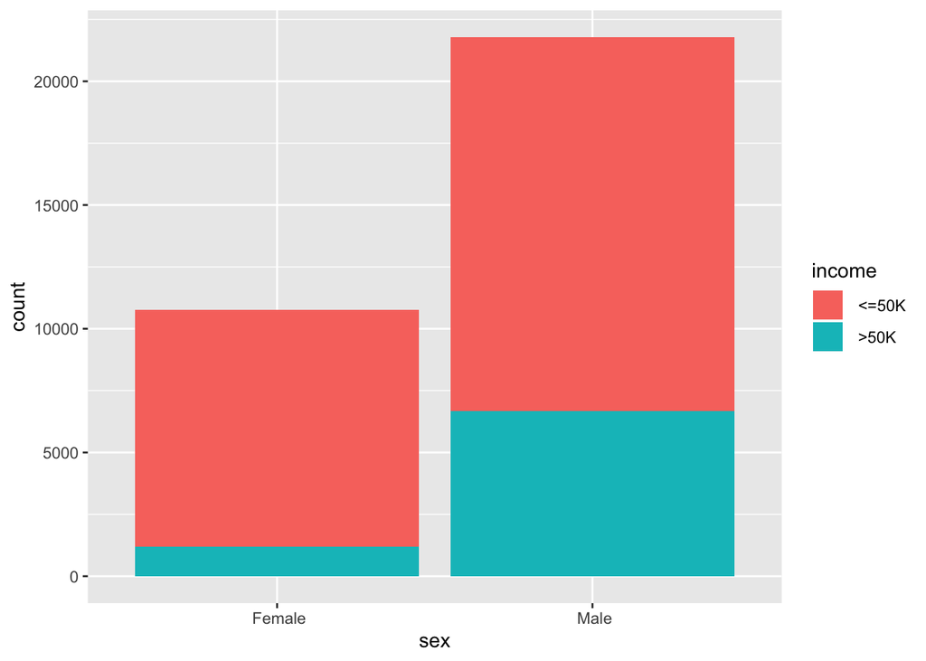

```r
#Empezamos por comprobar si el sexo puede ser un factor relevante.
ggplot (data = datosAdult, aes(x=sex, fill=income))+geom_bar()
```

El gráfico demuestra que, además de haber más hombres que mujeres en la muestra, la proporción de hombres en la porción azul es superior a la de mujeres, así que puede ser un factor importante.

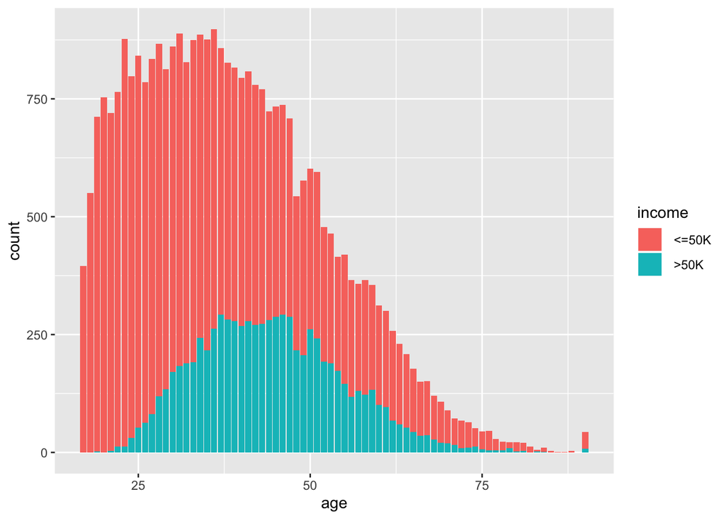

```r
#Ahora vamos a comprobar qué sucede desde el punto de vista de la edad.
ggplot (data = datosAdult, aes(x=age, fill=income))+geom_bar()
```

Vemos que entre los 40 y los 60 años aproximadamente es donde más casos existen en relación al resto de la población de la misma edad

```r
#A continuación vamos a discretizar algunos de los campos. Primero vemos cuáles nos podrían interesar:
apply(datosAdult,2, function(x) length(unique(x)))
```

```
##            age      workclass         fnlwgt      education  education-num
##             73              9          21648             16             16
## marital-status     occupation   relationship           race            sex
##              7             15              6              5              2
##   capital-gain   capital-loss  hour-per-week native-country         income
##            119             92             94             42              2
```

Seguramente las variable workclass y education pueden ser interesantes para este propósito, así que las pasaremos a factor

```r
cols<-c("workclass", "education")
for (i in cols){
datosAdult[,i] <- as.factor(datosAdult[,i])
}
#Esto nos permite ver los elementos en la categoría de cada una de estas variables.

summary(datosAdult$education)
```

```
##          10th          11th          12th       1st-4th       5th-6th
##           933          1175           433           168           333
##       7th-8th           9th    Assoc-acdm     Assoc-voc     Bachelors
##           646           514          1067          1382          5355
##     Doctorate       HS-grad       Masters     Preschool   Prof-school
##           413         10501          1723            51           576
##  Some-college
##          7291
```

A continuación voy a intentar ver si existe alguna relacion entre la educación y el sueldo.

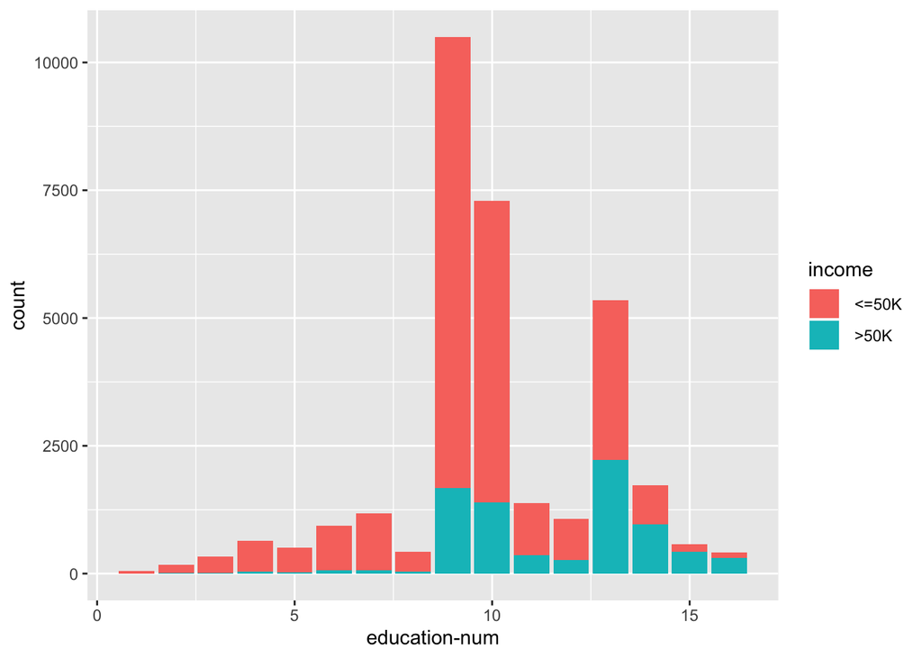

```r
ggplot (data = datosAdult, aes(x=`education-num`, fill=income))+geom_bar()
```

Con este sencillo gráfico nos damos cuenta de que “conforme avanza” el nivel de educación, nos encontramos más individuos con un sueldo superior a 50K

Vamos a ver si por sexo las proporciones son parecidas o cambian.

```r
#Para ello factorizamos la variable sexo
datosAdult$sex<-as.factor(datosAdult$sex)
```

Y ejecutamos el diagrama, que demuestra que, aunque las proporciones son parecidas, en algunos casos (como Masters, nivel 14) a mismo nivel educacional hay más proporción de hombres por encima de 50K que de mujeres

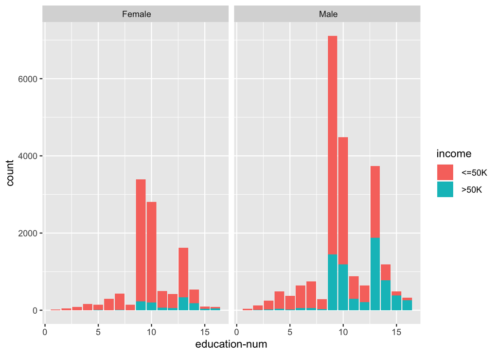

```r
ggplot (data = datosAdult, aes(x=`education-num`, fill=income))+geom_bar()+facet_wrap(datosAdult$sex)
```

En el gráfico observamos que, como cabía esperar, el porcentaje de personas por encima de 50K aumenta con la educación

Vamos a ver qué sucede desde el punto de vista de la workclass.

```r
#Obtenemos resumen de la variable, que ya fue factorizada
summary(datosAdult$workclass)
```

```
##                 ?       Federal-gov         Local-gov      Never-worked
##              1836               960              2093                 7
##           Private      Self-emp-inc  Self-emp-not-inc         State-gov
##             22696              1116              2541              1298
##       Without-pay
##                14
```

Observo que el gráfico sin manipular no me da una información útil

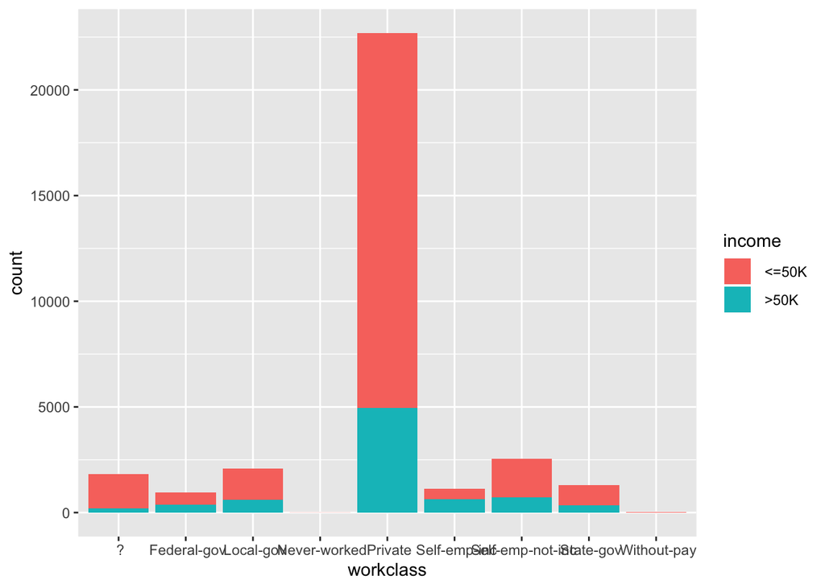

```r
ggplot (data = datosAdult, aes(x=workclass, fill=income))+geom_bar()
```

Así pues me propongo ver si los 50K se obtienen más proablemente en empleados públicos o privados. Voy a crear una nueva variable llamada “Sector”, donde podré tener los valores ‘Público’ o ‘Privado’. Además voy a a grupar ‘Federal-gov’, ‘Local-gov’ y ‘State-gov’ en el valor ‘Público’ mientras que ‘Private’ será ’Privado.

```r
#Copio el valor de workclass en Sector
datosAdult$Sector<-datosAdult$workclass
#Me aseguro de que ha ido como esperaba
summary(datosAdult$Sector)
```

```
##                 ?       Federal-gov         Local-gov      Never-worked
##              1836               960              2093                 7
##           Private      Self-emp-inc  Self-emp-not-inc         State-gov
##             22696              1116              2541              1298
##       Without-pay
##                14
```

```r
#Pongo a Públicos los que tiene cargo del gobierno
datosAdult$Sector <- gsub('Federal-gov', 'Público', datosAdult$Sector )
datosAdult$Sector<- gsub('Local-gov', 'Público', datosAdult$Sector )
datosAdult$Sector<- gsub('State-gov', 'Público', datosAdult$Sector )
#Pongo a privado el private

datosAdult$Sector<- gsub('Private', 'Privado', datosAdult$Sector )

datosAdult$Sector<-as.factor(datosAdult$Sector)

#Compruebo que he agrupado los valore privado y público
summary(datosAdult$Sector)
```

```
##                 ?      Never-worked           Privado           Público
##              1836                 7             22696              4351
##      Self-emp-inc  Self-emp-not-inc       Without-pay
##              1116              2541                14
```

Voy a centrarme en los valores “Público” y “Privado” que he determinado descartando el resto (a los que no he hecho ninguna manipulación)

```r
#Creo un DF auxiliar reduciendo dimensionalidad.
dfSector<- select(datosAdult, Sector, income, sex)
#Filtro los valores que me interesan descartando el resto.
dfSector<-filter(dfSector, Sector == " Privado" | Sector== " Público")
#Compruebo que lo he hecho correctamente
summary(dfSector)
```

```
##                Sector         income               sex
##   ?               :    0   Length:27047        Female: 9391
##   Never-worked    :    0   Class :character    Male  :17656
##   Privado         :22696   Mode  :character
##   Público         : 4351
##   Self-emp-inc    :    0
##   Self-emp-not-inc:    0
##   Without-pay     :    0
```

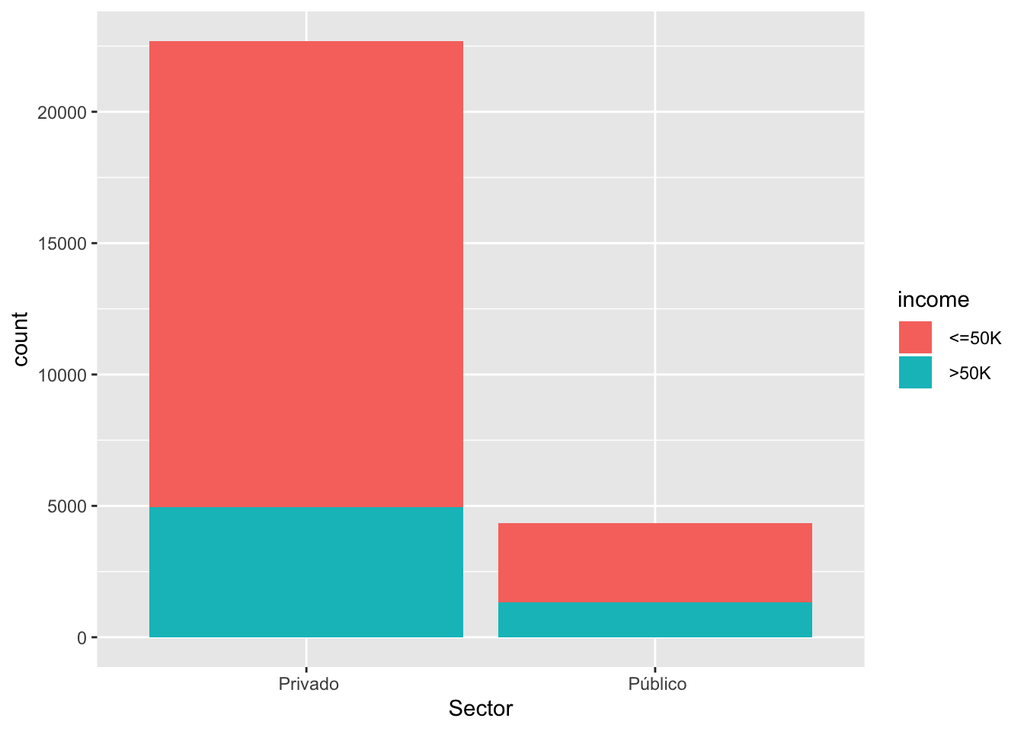

```r
#Lanzo un diagrama para ver la relación entre el sector y la renta
ggplot (data = dfSector, aes(x=Sector, fill=income))+geom_bar()
```

De este gráfico se deduce que las personas que están en el sector público, porcentualmente, tienen más probabilidad de tener una renta alta.

Vamos a comprobar si por sexos obtenemos un resultado parecido.

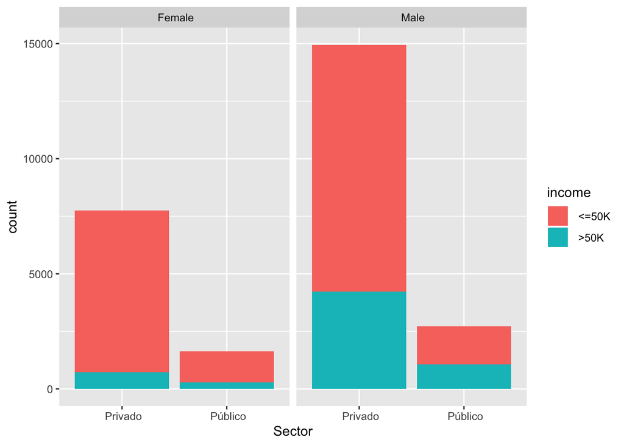

```r
ggplot (data = dfSector, aes(x=Sector, fill=income))+geom_bar()+facet_wrap(dfSector$sex)
```

Y vemos que de nuevo la tendencia es a que las mujeres alcanzan en menor porcentaje la cifra en ambos sectores.

Como conclusión de la práctica, he intentado analizar qué características favorecen que se rebasen los ingresos de 50K.

Hemos comprobado que el nivel de educación es un factor claramente importante y que las personas que tienen un empleo del gobierno tienen más probabilidad. También hemos visto que en algunos casos el sexo dificulta a las mujeres el acceso al salario superior.